# Tanzania Assignment 2

Group: Alona Sycheska

# 1 1. Load Data

```r
d18 <- read_dta("Tanzania_2018_new.dta")
glimpse(d18)
```

```
## Rows: 45,791
## Columns: 14
## $ REGION         <dbl+lbl> 1, 1, 1, 1, 1, 1, 1, 1, 1, 1, 1, 1, 1, 1, 1, 1, 1, …
## $ age            <dbl> 18, 7, 15, 18, 17, 12, 17, 15, 8, 9, 17, 12, 7, 15, 18,…
## $ hhweight       <dbl> 2654.3782, 1759.8087, 1437.1771, 1437.1771, 1437.1771, …
## $ popweight      <dbl> 18580.647, 8799.044, 11497.417, 4311.531, 7185.886, 843…
## $ LOC            <dbl+lbl> 1, 1, 1, 1, 1, 1, 1, 1, 1, 1, 1, 1, 1, 1, 1, 1, 1, …
## $ STRATUM        <dbl+lbl> 1, 1, 1, 1, 1, 1, 1, 1, 1, 1, 1, 1, 1, 1, 1, 1, 1, …
## $ povline        <dbl> 49320.13, 49320.13, 49320.13, 49320.13, 49320.13, 49320…
## $ cons           <dbl> 68496.26, 52976.13, 45638.08, 65462.32, 40867.90, 11933…
## $ CLUSTER        <dbl> 101021, 101091, 101201, 101201, 101201, 102023, 102023,…
## $ inschool       <dbl> 0, 0, 0, 0, 0, 0, 0, 0, 0, 0, 0, 0, 0, 0, 0, 0, 0, 0, 0…
## $ male           <dbl> 1, 0, 1, 0, 1, 0, 1, 0, 1, 1, 0, 1, 1, 1, 1, 0, 0, 1, 0…
## $ rural          <dbl> 1, 1, 1, 1, 1, 1, 1, 1, 1, 1, 1, 1, 1, 1, 1, 1, 1, 1, 1…
## $ freebooks      <dbl> 0, 1, 1, 1, 1, 1, 0, 0, 1, 1, 1, 1, 1, 0, 1, 1, 1, 1, 1…
## $ inschool_later <dbl> 0, 0, 0, 0, 0, 0, 0, 0, 0, 0, 0, 0, 0, 0, 0, 0, 1, 0, 0…
```

# 2 2. Poverty Indicator

```r
d18 <- d18 %>% mutate(poor_nat = if_else(cons < povline, 1L, 0L))
table(d18$poor_nat)
```

```
##
##     0     1
## 33059 12732
```

**Answer:**  
A person is considered poor if `cons < povline`. This matches the national poverty line definition.

# 3 3. Percent of Children in School (2018)

```r
d18_children <- d18 %>%
  mutate(
    loc = if_else(rural == 1, "Rural", "Urban"),
    sex = if_else(male == 1, "Male", "Female"),
    age_group = case_when(
      age >= 7 & age <= 12 ~ "7-12",
      age >= 13 & age <= 18 ~ "13-18",
      TRUE ~ NA_character_
    )
  ) %>%
  filter(poor_nat == 1, !is.na(age_group), !is.na(inschool))

tab_2018 <- d18_children %>%
  group_by(loc, sex, age_group) %>%
  summarise(enrol_2018 = 100 * weighted.mean(inschool == 1, w = hhweight, na.rm = TRUE))
kable(tab_2018)
```

| loc | sex | age_group | enrol_2018 |
| --- | --- | --- | --- |
| Rural | Female | 13-18 | 52.13535 |
| Rural | Female | 7-12 | 85.00921 |
| Rural | Male | 13-18 | 53.22292 |
| Rural | Male | 7-12 | 82.83298 |
| Urban | Female | 13-18 | 65.43029 |
| Urban | Female | 7-12 | 94.70680 |
| Urban | Male | 13-18 | 64.72902 |
| Urban | Male | 7-12 | 93.04736 |

## 3.1 Graph 1: Enrollment Rates in 2018 by Group

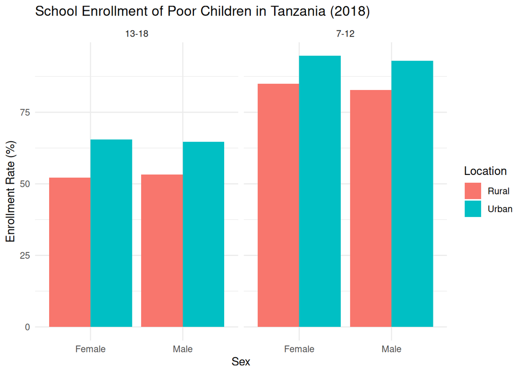

```r
ggplot(tab_2018, aes(x=sex, y=enrol_2018, fill=loc)) +
  geom_col(position="dodge") +
  facet_wrap(~age_group) +
  labs(title="School Enrollment of Poor Children in Tanzania (2018)",
       y="Enrollment Rate (%)",
       x="Sex",
       fill="Location") +
  theme_minimal()
```

# 4 4. Comparison with Banerjee & Duflo (Table 9)

```r
tab_bd <- tibble::tribble(
  ~loc, ~sex, ~age_group, ~enrol_2004,
  "Rural","Female","7-12",51.2,
  "Rural","Male","7-12",47.2,
  "Urban","Female","7-12",66.4,
  "Urban","Male","7-12",54.4,
  "Rural","Female","13-18",53.3,
  "Rural","Male","13-18",61.4,
  "Urban","Female","13-18",51.8,
  "Urban","Male","13-18",65.3
)

comp <- inner_join(tab_bd, tab_2018, by=c("loc","sex","age_group")) %>%
  mutate(change_pp = enrol_2018 - enrol_2004)

kable(comp)
```

| loc | sex | age_group | enrol_2004 | enrol_2018 | change_pp |
| --- | --- | --- | --- | --- | --- |
| Rural | Female | 7-12 | 51.2 | 85.00921 | 33.8092114 |
| Rural | Male | 7-12 | 47.2 | 82.83298 | 35.6329810 |
| Urban | Female | 7-12 | 66.4 | 94.70680 | 28.3068035 |
| Urban | Male | 7-12 | 54.4 | 93.04736 | 38.6473607 |
| Rural | Female | 13-18 | 53.3 | 52.13535 | -1.1646527 |
| Rural | Male | 13-18 | 61.4 | 53.22292 | -8.1770799 |
| Urban | Female | 13-18 | 51.8 | 65.43029 | 13.6302874 |
| Urban | Male | 13-18 | 65.3 | 64.72902 | -0.5709805 |

## 4.1 Graph 2: Change Over Time (2004 vs 2018)

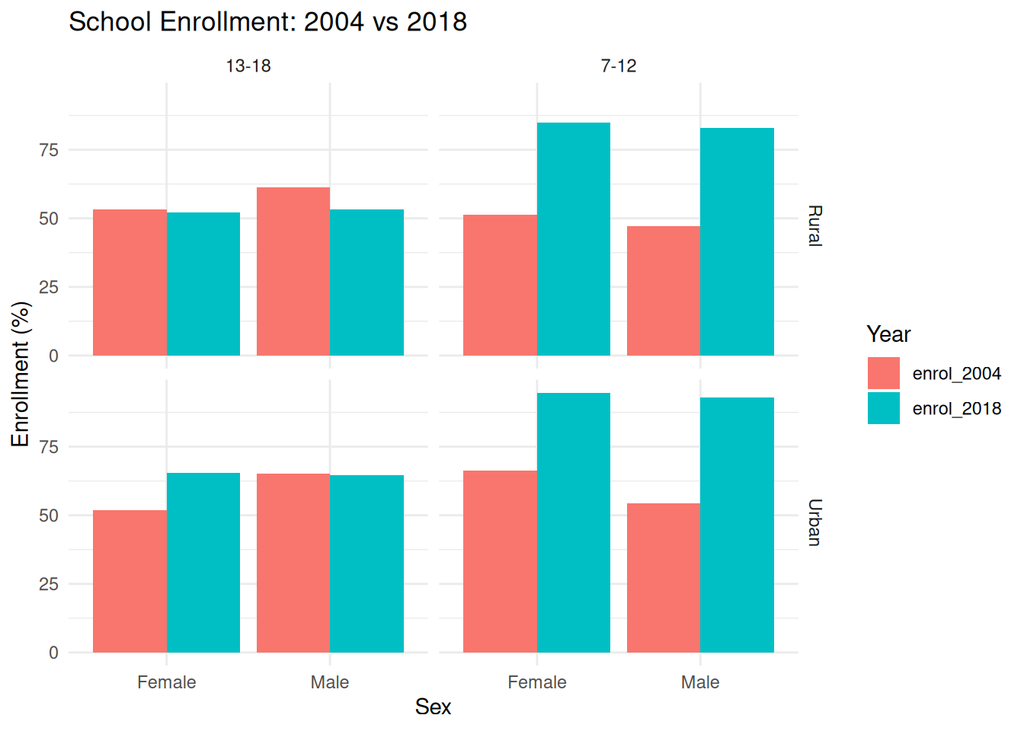

```r
comp_long <- comp %>%
  pivot_longer(cols=c(enrol_2004, enrol_2018), names_to="year", values_to="value")

ggplot(comp_long, aes(x=sex, y=value, fill=year)) +
  geom_col(position="dodge") +
  facet_grid(loc ~ age_group) +
  labs(title="School Enrollment: 2004 vs 2018",
       x="Sex",
       y="Enrollment (%)",
       fill="Year") +
  theme_minimal()
```

# 5 Policy Note

**Background:**  
Enrollment among poor Tanzanian children has changed between early-2000s and 2018. The goal is to understand improvements and remaining gaps.

**Interpretation:**  
- Gains reflect national policies boosting primary education.  
- Rural improvements may come from infrastructure investments.  
- Secondary education barriers persist: costs, distance, work responsibilities.

**Policy Recommendations:**  
- Expand support for secondary education (books, uniforms, transport).  
- Provide cash transfers for rural poor households.  
- Support adolescent girls via targeted programs.

# 6 5. RCT: Free Books

```r
rct <- d18 %>%
  filter(age >= 7, age <= 12) %>%
  mutate(
    loc = factor(if_else(rural == 1, "Rural","Urban")),
    sex = factor(if_else(male == 1, "Male","Female"))
  )

rct_tab <- rct %>%
  group_by(freebooks) %>%
  summarise(enrol_later = 100 * weighted.mean(inschool_later == 1, w = hhweight, na.rm = TRUE))

kable(rct_tab)
```

| freebooks | enrol_later |
| --- | --- |
| 0 | 90.17491 |
| 1 | 91.15238 |

## 6.1 Graph 3: RCT Treatment vs Control Enrollment

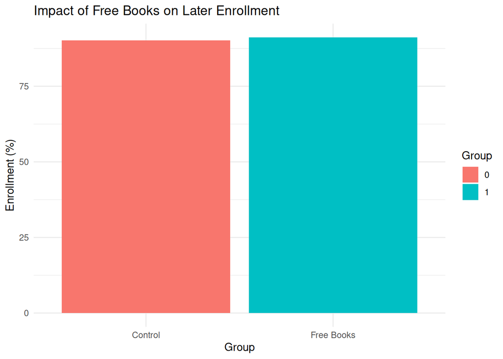

```r
ggplot(rct_tab, aes(x=factor(freebooks), y=enrol_later, fill=factor(freebooks))) +
  geom_col() +
  scale_x_discrete(labels=c("0"="Control","1"="Free Books")) +
  labs(title="Impact of Free Books on Later Enrollment",
       x="Group",
       y="Enrollment (%)",
       fill="Group") +
  theme_minimal()
```

# 7 6. Regression Analysis

## 7.1 6.1 Main Treatment Effect

```r
lm1 <- lm(inschool_later ~ freebooks, data=rct, weights=hhweight)
kable(tidy(lm1))
```

| term | estimate | std.error | statistic | p.value |
| --- | --- | --- | --- | --- |
| (Intercept) | 0.9017491 | 0.0046232 | 195.050493 | 0.0000000 |
| freebooks | 0.0097747 | 0.0065683 | 1.488165 | 0.1367475 |

### 7.1.1 Interpretation

- The coefficient on **freebooks** represents the estimated increase in enrollment probability caused by receiving free books.
- A positive and statistically significant coefficient indicates the program improved school attendance.

## 7.2 6.2 Controlled Regression

```r
lm2 <- lm(inschool_later ~ freebooks + age + sex + loc, data=rct, weights=hhweight)
kable(tidy(lm2))
```

| term | estimate | std.error | statistic | p.value |
| --- | --- | --- | --- | --- |
| (Intercept) | 0.8436506 | 0.0186502 | 45.235494 | 0.0000000 |
| freebooks | 0.0081617 | 0.0065079 | 1.254111 | 0.2098391 |
| age | 0.0044821 | 0.0018729 | 2.393132 | 0.0167286 |
| sexMale | -0.0149876 | 0.0065068 | -2.303364 | 0.0212844 |
| locUrban | 0.0893829 | 0.0073486 | 12.163199 | 0.0000000 |

### 7.2.1 Interpretation

- Adding controls removes variation related to demographics.
- If the coefficient remains positive and significant, the treatment effect is robust.

## 7.3 6.3 Graph: Predicted Probabilities

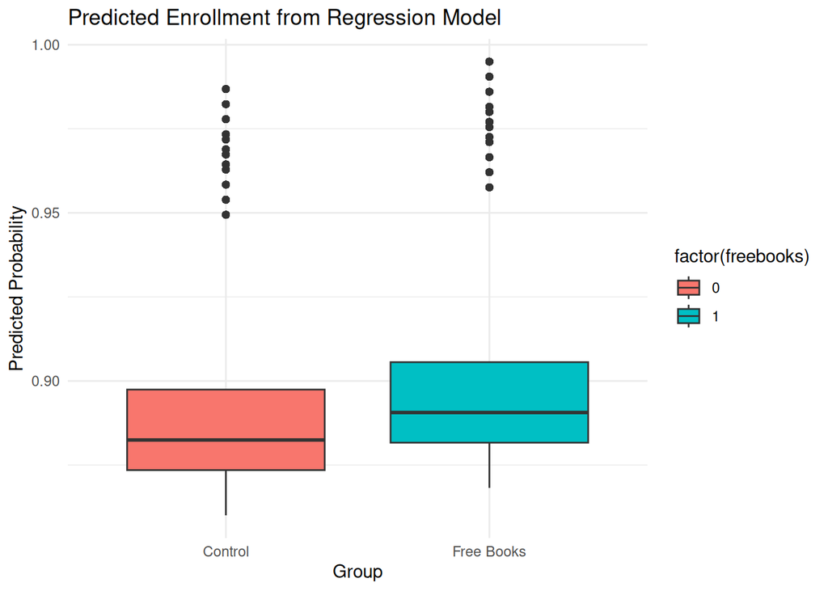

```r
rct$predicted <- predict(lm2)

ggplot(rct, aes(x=factor(freebooks), y=predicted, fill=factor(freebooks))) +
  geom_boxplot() +
  scale_x_discrete(labels=c("0"="Control","1"="Free Books")) +
  labs(
    title="Predicted Enrollment from Regression Model",
    x="Group",
    y="Predicted Probability"
  ) +
  theme_minimal()
```

This graph shows differences in predicted enrollment between groups after adjusting for age, sex, and location.